# Risk Factor Analysis

## Outcome Variable

**Outcome Variable:** swasted

## Predictor Variables

**Intervention Variable:** birthwt

**Adjustment Set:**

- arm
- sex
- W_mage
- meducyrs
- feducyrs
- vagbrth
- single
- brthmon
- W_parity
- delta_W_mage
- delta_meducyrs
- delta_feducyrs
- delta_vagbrth
- delta_single
- delta_brthmon
- delta_W_parity

## Stratifying Variables

The analysis was stratified on these variable(s):

- agecat
- studyid
- country

## Data Summary

| agecat | studyid | country | birthwt | swasted | n_cell | n |
| --- | --- | --- | --- | --- | --- | --- |
| Birth | ki0047075b-MAL-ED | BANGLADESH | Normal or high birthweight | 0 | 197 | 241 |
| Birth | ki0047075b-MAL-ED | BANGLADESH | Normal or high birthweight | 1 | 5 | 241 |
| Birth | ki0047075b-MAL-ED | BANGLADESH | Low birth weight | 0 | 36 | 241 |
| Birth | ki0047075b-MAL-ED | BANGLADESH | Low birth weight | 1 | 3 | 241 |
| Birth | ki0047075b-MAL-ED | BRAZIL | Normal or high birthweight | 0 | 179 | 183 |
| Birth | ki0047075b-MAL-ED | BRAZIL | Normal or high birthweight | 1 | 0 | 183 |
| Birth | ki0047075b-MAL-ED | BRAZIL | Low birth weight | 0 | 4 | 183 |
| Birth | ki0047075b-MAL-ED | BRAZIL | Low birth weight | 1 | 0 | 183 |
| Birth | ki0047075b-MAL-ED | INDIA | Normal or high birthweight | 0 | 168 | 203 |
| Birth | ki0047075b-MAL-ED | INDIA | Normal or high birthweight | 1 | 3 | 203 |
| Birth | ki0047075b-MAL-ED | INDIA | Low birth weight | 0 | 28 | 203 |
| Birth | ki0047075b-MAL-ED | INDIA | Low birth weight | 1 | 4 | 203 |
| Birth | ki0047075b-MAL-ED | NEPAL | Normal or high birthweight | 0 | 152 | 168 |
| Birth | ki0047075b-MAL-ED | NEPAL | Normal or high birthweight | 1 | 3 | 168 |
| Birth | ki0047075b-MAL-ED | NEPAL | Low birth weight | 0 | 12 | 168 |
| Birth | ki0047075b-MAL-ED | NEPAL | Low birth weight | 1 | 1 | 168 |
| Birth | ki0047075b-MAL-ED | PERU | Normal or high birthweight | 0 | 265 | 279 |
| Birth | ki0047075b-MAL-ED | PERU | Normal or high birthweight | 1 | 0 | 279 |
| Birth | ki0047075b-MAL-ED | PERU | Low birth weight | 0 | 14 | 279 |
| Birth | ki0047075b-MAL-ED | PERU | Low birth weight | 1 | 0 | 279 |
| Birth | ki0047075b-MAL-ED | SOUTH AFRICA | Normal or high birthweight | 0 | 242 | 258 |
| Birth | ki0047075b-MAL-ED | SOUTH AFRICA | Normal or high birthweight | 1 | 2 | 258 |
| Birth | ki0047075b-MAL-ED | SOUTH AFRICA | Low birth weight | 0 | 14 | 258 |
| Birth | ki0047075b-MAL-ED | SOUTH AFRICA | Low birth weight | 1 | 0 | 258 |
| Birth | ki0047075b-MAL-ED | TANZANIA, UNITED REPUBLIC OF | Normal or high birthweight | 0 | 112 | 118 |
| Birth | ki0047075b-MAL-ED | TANZANIA, UNITED REPUBLIC OF | Normal or high birthweight | 1 | 1 | 118 |
| Birth | ki0047075b-MAL-ED | TANZANIA, UNITED REPUBLIC OF | Low birth weight | 0 | 5 | 118 |
| Birth | ki0047075b-MAL-ED | TANZANIA, UNITED REPUBLIC OF | Low birth weight | 1 | 0 | 118 |
| Birth | ki1000108-CMC-V-BCS-2002 | INDIA | Normal or high birthweight | 0 | 75 | 88 |
| Birth | ki1000108-CMC-V-BCS-2002 | INDIA | Normal or high birthweight | 1 | 4 | 88 |

[output cut: 286 more lines]

The following strata were considered:

- agecat: 24 months, studyid: ki0047075b-MAL-ED, country: BANGLADESH
- agecat: 24 months, studyid: ki0047075b-MAL-ED, country: BRAZIL
- agecat: 24 months, studyid: ki0047075b-MAL-ED, country: INDIA
- agecat: 24 months, studyid: ki0047075b-MAL-ED, country: NEPAL
- agecat: 24 months, studyid: ki0047075b-MAL-ED, country: PERU
- agecat: 24 months, studyid: ki0047075b-MAL-ED, country: SOUTH AFRICA
- agecat: 24 months, studyid: ki0047075b-MAL-ED, country: TANZANIA, UNITED REPUBLIC OF
- agecat: 24 months, studyid: ki1000108-CMC-V-BCS-2002, country: INDIA
- agecat: 24 months, studyid: ki1000108-IRC, country: INDIA
- agecat: 24 months, studyid: ki1017093-NIH-Birth, country: BANGLADESH
- agecat: 24 months, studyid: ki1017093b-PROVIDE, country: BANGLADESH
- agecat: 24 months, studyid: ki1017093c-NIH-Crypto, country: BANGLADESH
- agecat: 24 months, studyid: ki1066203-TanzaniaChild2, country: TANZANIA, UNITED REPUBLIC OF
- agecat: 24 months, studyid: ki1101329-Keneba, country: GAMBIA
- agecat: 24 months, studyid: ki1114097-CMIN, country: BANGLADESH
- agecat: 24 months, studyid: ki1114097-CMIN, country: PERU
- agecat: 24 months, studyid: ki1114097-CONTENT, country: PERU
- agecat: 24 months, studyid: ki1119695-PROBIT, country: BELARUS
- agecat: 24 months, studyid: ki1126311-ZVITAMBO, country: ZIMBABWE
- agecat: 24 months, studyid: ki1135781-COHORTS, country: GUATEMALA
- agecat: 24 months, studyid: ki1135781-COHORTS, country: INDIA
- agecat: 24 months, studyid: ki1135781-COHORTS, country: PHILIPPINES
- agecat: 24 months, studyid: kiGH5241-JiVitA-3, country: BANGLADESH
- agecat: 24 months, studyid: kiGH5241-JiVitA-4, country: BANGLADESH
- agecat: 6 months, studyid: ki0047075b-MAL-ED, country: BANGLADESH
- agecat: 6 months, studyid: ki0047075b-MAL-ED, country: BRAZIL
- agecat: 6 months, studyid: ki0047075b-MAL-ED, country: INDIA
- agecat: 6 months, studyid: ki0047075b-MAL-ED, country: NEPAL
- agecat: 6 months, studyid: ki0047075b-MAL-ED, country: PERU
- agecat: 6 months, studyid: ki0047075b-MAL-ED, country: SOUTH AFRICA
- agecat: 6 months, studyid: ki0047075b-MAL-ED, country: TANZANIA, UNITED REPUBLIC OF
- agecat: 6 months, studyid: ki1000108-CMC-V-BCS-2002, country: INDIA
- agecat: 6 months, studyid: ki1000108-IRC, country: INDIA
- agecat: 6 months, studyid: ki1000109-EE, country: PAKISTAN
- agecat: 6 months, studyid: ki1000109-ResPak, country: PAKISTAN
- agecat: 6 months, studyid: ki1000304b-SAS-CompFeed, country: INDIA
- agecat: 6 months, studyid: ki1017093-NIH-Birth, country: BANGLADESH
- agecat: 6 months, studyid: ki1017093b-PROVIDE, country: BANGLADESH
- agecat: 6 months, studyid: ki1017093c-NIH-Crypto, country: BANGLADESH
- agecat: 6 months, studyid: ki1066203-TanzaniaChild2, country: TANZANIA, UNITED REPUBLIC OF
- agecat: 6 months, studyid: ki1101329-Keneba, country: GAMBIA
- agecat: 6 months, studyid: ki1114097-CMIN, country: BANGLADESH
- agecat: 6 months, studyid: ki1114097-CMIN, country: BRAZIL
- agecat: 6 months, studyid: ki1114097-CMIN, country: GUINEA-BISSAU
- agecat: 6 months, studyid: ki1114097-CMIN, country: PERU
- agecat: 6 months, studyid: ki1114097-CONTENT, country: PERU
- agecat: 6 months, studyid: ki1119695-PROBIT, country: BELARUS
- agecat: 6 months, studyid: ki1126311-ZVITAMBO, country: ZIMBABWE
- agecat: 6 months, studyid: ki1135781-COHORTS, country: GUATEMALA
- agecat: 6 months, studyid: ki1135781-COHORTS, country: INDIA
- agecat: 6 months, studyid: ki1135781-COHORTS, country: PHILIPPINES
- agecat: 6 months, studyid: kiGH5241-JiVitA-3, country: BANGLADESH
- agecat: 6 months, studyid: kiGH5241-JiVitA-4, country: BANGLADESH
- agecat: Birth, studyid: ki0047075b-MAL-ED, country: BANGLADESH
- agecat: Birth, studyid: ki0047075b-MAL-ED, country: BRAZIL
- agecat: Birth, studyid: ki0047075b-MAL-ED, country: INDIA
- agecat: Birth, studyid: ki0047075b-MAL-ED, country: NEPAL
- agecat: Birth, studyid: ki0047075b-MAL-ED, country: PERU
- agecat: Birth, studyid: ki0047075b-MAL-ED, country: SOUTH AFRICA
- agecat: Birth, studyid: ki0047075b-MAL-ED, country: TANZANIA, UNITED REPUBLIC OF
- agecat: Birth, studyid: ki1000108-CMC-V-BCS-2002, country: INDIA
- agecat: Birth, studyid: ki1000108-IRC, country: INDIA
- agecat: Birth, studyid: ki1000109-EE, country: PAKISTAN
- agecat: Birth, studyid: ki1000109-ResPak, country: PAKISTAN
- agecat: Birth, studyid: ki1000304b-SAS-CompFeed, country: INDIA
- agecat: Birth, studyid: ki1017093-NIH-Birth, country: BANGLADESH
- agecat: Birth, studyid: ki1017093c-NIH-Crypto, country: BANGLADESH
- agecat: Birth, studyid: ki1101329-Keneba, country: GAMBIA
- agecat: Birth, studyid: ki1114097-CMIN, country: BANGLADESH
- agecat: Birth, studyid: ki1114097-CMIN, country: BRAZIL
- agecat: Birth, studyid: ki1114097-CMIN, country: PERU
- agecat: Birth, studyid: ki1114097-CONTENT, country: PERU
- agecat: Birth, studyid: ki1119695-PROBIT, country: BELARUS
- agecat: Birth, studyid: ki1126311-ZVITAMBO, country: ZIMBABWE
- agecat: Birth, studyid: ki1135781-COHORTS, country: GUATEMALA
- agecat: Birth, studyid: ki1135781-COHORTS, country: INDIA
- agecat: Birth, studyid: ki1135781-COHORTS, country: PHILIPPINES
- agecat: Birth, studyid: kiGH5241-JiVitA-3, country: BANGLADESH
- agecat: Birth, studyid: kiGH5241-JiVitA-4, country: BANGLADESH

### Dropped Strata

Some strata were dropped due to rare outcomes:

- agecat: Birth, studyid: ki0047075b-MAL-ED, country: BANGLADESH
- agecat: Birth, studyid: ki0047075b-MAL-ED, country: BRAZIL
- agecat: Birth, studyid: ki0047075b-MAL-ED, country: INDIA
- agecat: Birth, studyid: ki0047075b-MAL-ED, country: NEPAL
- agecat: Birth, studyid: ki0047075b-MAL-ED, country: PERU
- agecat: Birth, studyid: ki0047075b-MAL-ED, country: SOUTH AFRICA
- agecat: Birth, studyid: ki0047075b-MAL-ED, country: TANZANIA, UNITED REPUBLIC OF
- agecat: Birth, studyid: ki1000108-CMC-V-BCS-2002, country: INDIA
- agecat: Birth, studyid: ki1000109-EE, country: PAKISTAN
- agecat: Birth, studyid: ki1000109-ResPak, country: PAKISTAN
- agecat: Birth, studyid: ki1000304b-SAS-CompFeed, country: INDIA
- agecat: Birth, studyid: ki1017093-NIH-Birth, country: BANGLADESH
- agecat: Birth, studyid: ki1017093c-NIH-Crypto, country: BANGLADESH
- agecat: Birth, studyid: ki1114097-CMIN, country: BANGLADESH
- agecat: Birth, studyid: ki1114097-CMIN, country: BRAZIL
- agecat: Birth, studyid: ki1114097-CMIN, country: PERU
- agecat: Birth, studyid: ki1114097-CONTENT, country: PERU
- agecat: Birth, studyid: ki1119695-PROBIT, country: BELARUS
- agecat: Birth, studyid: kiGH5241-JiVitA-4, country: BANGLADESH
- agecat: 6 months, studyid: ki0047075b-MAL-ED, country: BANGLADESH
- agecat: 6 months, studyid: ki0047075b-MAL-ED, country: BRAZIL
- agecat: 6 months, studyid: ki0047075b-MAL-ED, country: INDIA
- agecat: 6 months, studyid: ki0047075b-MAL-ED, country: NEPAL
- agecat: 6 months, studyid: ki0047075b-MAL-ED, country: PERU
- agecat: 6 months, studyid: ki0047075b-MAL-ED, country: SOUTH AFRICA
- agecat: 6 months, studyid: ki0047075b-MAL-ED, country: TANZANIA, UNITED REPUBLIC OF
- agecat: 6 months, studyid: ki1000108-CMC-V-BCS-2002, country: INDIA
- agecat: 6 months, studyid: ki1000109-EE, country: PAKISTAN
- agecat: 6 months, studyid: ki1000109-ResPak, country: PAKISTAN
- agecat: 6 months, studyid: ki1017093-NIH-Birth, country: BANGLADESH
- agecat: 6 months, studyid: ki1017093b-PROVIDE, country: BANGLADESH
- agecat: 6 months, studyid: ki1017093c-NIH-Crypto, country: BANGLADESH
- agecat: 6 months, studyid: ki1066203-TanzaniaChild2, country: TANZANIA, UNITED REPUBLIC OF
- agecat: 6 months, studyid: ki1101329-Keneba, country: GAMBIA
- agecat: 6 months, studyid: ki1114097-CMIN, country: BANGLADESH
- agecat: 6 months, studyid: ki1114097-CMIN, country: BRAZIL
- agecat: 6 months, studyid: ki1114097-CMIN, country: GUINEA-BISSAU
- agecat: 6 months, studyid: ki1114097-CMIN, country: PERU
- agecat: 6 months, studyid: ki1114097-CONTENT, country: PERU
- agecat: 6 months, studyid: ki1119695-PROBIT, country: BELARUS
- agecat: 6 months, studyid: ki1135781-COHORTS, country: GUATEMALA
- agecat: 24 months, studyid: ki0047075b-MAL-ED, country: BANGLADESH
- agecat: 24 months, studyid: ki0047075b-MAL-ED, country: BRAZIL
- agecat: 24 months, studyid: ki0047075b-MAL-ED, country: INDIA
- agecat: 24 months, studyid: ki0047075b-MAL-ED, country: NEPAL
- agecat: 24 months, studyid: ki0047075b-MAL-ED, country: PERU
- agecat: 24 months, studyid: ki0047075b-MAL-ED, country: SOUTH AFRICA
- agecat: 24 months, studyid: ki0047075b-MAL-ED, country: TANZANIA, UNITED REPUBLIC OF
- agecat: 24 months, studyid: ki1000108-CMC-V-BCS-2002, country: INDIA
- agecat: 24 months, studyid: ki1000108-IRC, country: INDIA
- agecat: 24 months, studyid: ki1017093-NIH-Birth, country: BANGLADESH
- agecat: 24 months, studyid: ki1017093b-PROVIDE, country: BANGLADESH
- agecat: 24 months, studyid: ki1017093c-NIH-Crypto, country: BANGLADESH
- agecat: 24 months, studyid: ki1066203-TanzaniaChild2, country: TANZANIA, UNITED REPUBLIC OF
- agecat: 24 months, studyid: ki1101329-Keneba, country: GAMBIA
- agecat: 24 months, studyid: ki1114097-CMIN, country: BANGLADESH
- agecat: 24 months, studyid: ki1114097-CMIN, country: PERU
- agecat: 24 months, studyid: ki1114097-CONTENT, country: PERU
- agecat: 24 months, studyid: ki1119695-PROBIT, country: BELARUS
- agecat: 24 months, studyid: ki1135781-COHORTS, country: GUATEMALA
- agecat: 24 months, studyid: ki1135781-COHORTS, country: PHILIPPINES

## Methods Detail

We’re interested in the causal parameters $E[Y_a]$ for all values of $a \in \mathcal{A}$. These parameters represent the mean outcome if, possibly contrary to fact, we intervened to set all units to have $A=a$. Under the randomization and positivity assumptions, these are identified by the statistical parameters $\psi_a=E_W[E_{Y|A,W}(Y|A=a,W)]$. In addition, we’re interested in the mean of $Y$, $E[Y]$ under no intervention (the observed mean). We will estimate these parameters by using SuperLearner to fit the relevant likelihood factors – $E_{Y|A,W}(Y|A=a,W)$ and $p(A=a|W)$, and then updating our likelihood fit using a joint TMLE.

For unadjusted analyses ($W=\{\}$), initial likelihoods were estimated using Lrnr_glm to estimate the simple $E(Y|A)$ and Lrnr_mean to estimate $p(A)$. For adjusted analyses, a small library containing Lrnr_glmnet, Lrnr_xgboost, and Lrnr_mean was used.

Having estimated these parameters, we will then use the delta method to estimate relative risks and attributable risks relative to a prespecified baseline level of $A$.

# Results Detail

## Results Plots

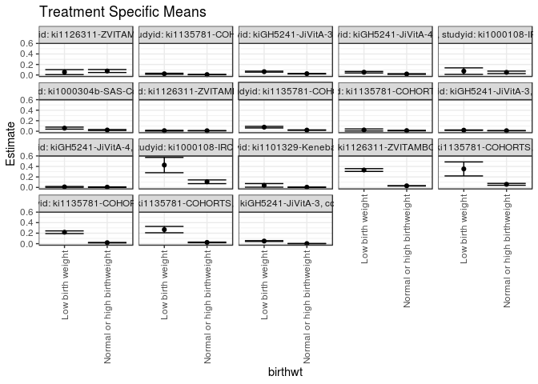

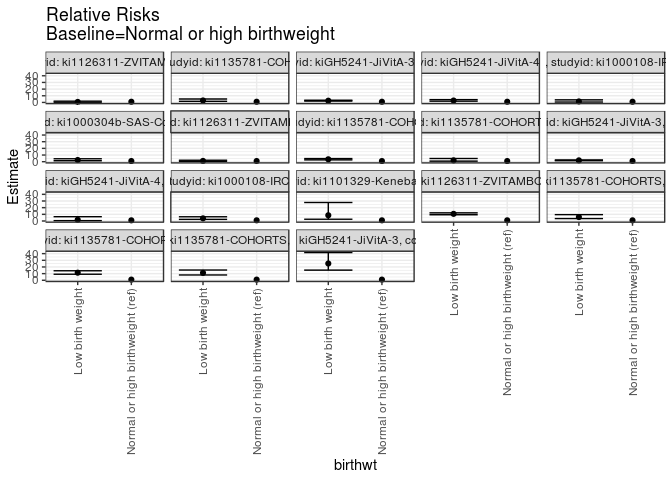

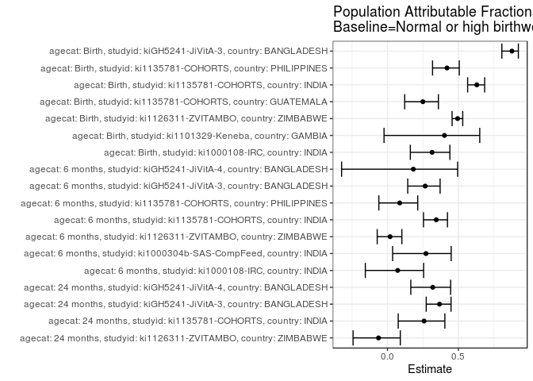

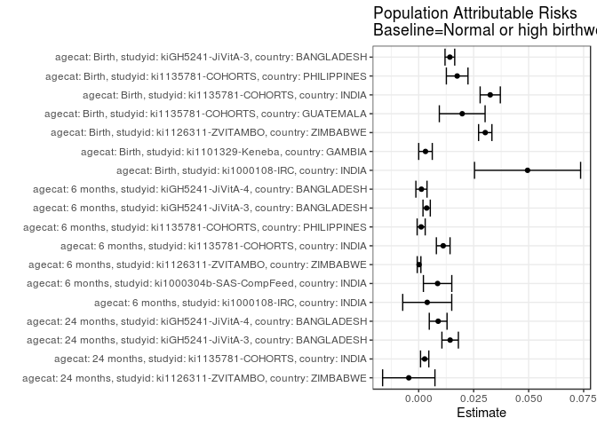

## Results Table

### Parameter: TSM

| agecat | studyid | country | intervention_level | baseline_level | estimate | ci_lower | ci_upper |
| --- | --- | --- | --- | --- | --- | --- | --- |
| Birth | ki1000108-IRC | INDIA | Normal or high birthweight | NA | 0.1079271 | 0.0724118 | 0.1434424 |
| Birth | ki1000108-IRC | INDIA | Low birth weight | NA | 0.4259764 | 0.2804623 | 0.5714906 |
| Birth | ki1101329-Keneba | GAMBIA | Normal or high birthweight | NA | 0.0046261 | 0.0009318 | 0.0083203 |
| Birth | ki1101329-Keneba | GAMBIA | Low birth weight | NA | 0.0396825 | 0.0055850 | 0.0737800 |
| Birth | ki1126311-ZVITAMBO | ZIMBABWE | Normal or high birthweight | NA | 0.0309714 | 0.0278182 | 0.0341245 |
| Birth | ki1126311-ZVITAMBO | ZIMBABWE | Low birth weight | NA | 0.3315407 | 0.3052318 | 0.3578497 |
| Birth | ki1135781-COHORTS | GUATEMALA | Normal or high birthweight | NA | 0.0595685 | 0.0420458 | 0.0770912 |
| Birth | ki1135781-COHORTS | GUATEMALA | Low birth weight | NA | 0.3522647 | 0.2188035 | 0.4857259 |
| Birth | ki1135781-COHORTS | INDIA | Normal or high birthweight | NA | 0.0191355 | 0.0153981 | 0.0228729 |
| Birth | ki1135781-COHORTS | INDIA | Low birth weight | NA | 0.2177717 | 0.1923071 | 0.2432363 |
| Birth | ki1135781-COHORTS | PHILIPPINES | Normal or high birthweight | NA | 0.0242338 | 0.0184139 | 0.0300536 |
| Birth | ki1135781-COHORTS | PHILIPPINES | Low birth weight | NA | 0.2678948 | 0.2073113 | 0.3284783 |
| Birth | kiGH5241-JiVitA-3 | BANGLADESH | Normal or high birthweight | NA | 0.0019829 | 0.0010097 | 0.0029560 |
| Birth | kiGH5241-JiVitA-3 | BANGLADESH | Low birth weight | NA | 0.0499222 | 0.0425533 | 0.0572910 |
| 6 months | ki1000108-IRC | INDIA | Normal or high birthweight | NA | 0.0502959 | 0.0269674 | 0.0736243 |
| 6 months | ki1000108-IRC | INDIA | Low birth weight | NA | 0.0735294 | 0.0114174 | 0.1356414 |
| 6 months | ki1000304b-SAS-CompFeed | INDIA | Normal or high birthweight | NA | 0.0231155 | 0.0137278 | 0.0325032 |
| 6 months | ki1000304b-SAS-CompFeed | INDIA | Low birth weight | NA | 0.0587496 | 0.0396008 | 0.0778983 |
| 6 months | ki1126311-ZVITAMBO | ZIMBABWE | Normal or high birthweight | NA | 0.0094184 | 0.0071869 | 0.0116499 |
| 6 months | ki1126311-ZVITAMBO | ZIMBABWE | Low birth weight | NA | 0.0109389 | 0.0044801 | 0.0173978 |
| 6 months | ki1135781-COHORTS | INDIA | Normal or high birthweight | NA | 0.0213107 | 0.0173050 | 0.0253163 |
| 6 months | ki1135781-COHORTS | INDIA | Low birth weight | NA | 0.0771294 | 0.0623101 | 0.0919487 |
| 6 months | ki1135781-COHORTS | PHILIPPINES | Normal or high birthweight | NA | 0.0120033 | 0.0076601 | 0.0163465 |
| 6 months | ki1135781-COHORTS | PHILIPPINES | Low birth weight | NA | 0.0241935 | 0.0050671 | 0.0433200 |
| 6 months | kiGH5241-JiVitA-3 | BANGLADESH | Normal or high birthweight | NA | 0.0100181 | 0.0078623 | 0.0121739 |
| 6 months | kiGH5241-JiVitA-3 | BANGLADESH | Low birth weight | NA | 0.0200199 | 0.0158965 | 0.0241433 |
| 6 months | kiGH5241-JiVitA-4 | BANGLADESH | Normal or high birthweight | NA | 0.0056614 | 0.0003140 | 0.0110089 |
| 6 months | kiGH5241-JiVitA-4 | BANGLADESH | Low birth weight | NA | 0.0105538 | 0.0022473 | 0.0188604 |
| 24 months | ki1126311-ZVITAMBO | ZIMBABWE | Normal or high birthweight | NA | 0.0757576 | 0.0471742 | 0.1043410 |
| 24 months | ki1126311-ZVITAMBO | ZIMBABWE | Low birth weight | NA | 0.0549451 | 0.0080706 | 0.1018196 |
| 24 months | ki1135781-COHORTS | INDIA | Normal or high birthweight | NA | 0.0078493 | 0.0050893 | 0.0106093 |
| 24 months | ki1135781-COHORTS | INDIA | Low birth weight | NA | 0.0228893 | 0.0128493 | 0.0329293 |
| 24 months | kiGH5241-JiVitA-3 | BANGLADESH | Normal or high birthweight | NA | 0.0247322 | 0.0203410 | 0.0291233 |
| 24 months | kiGH5241-JiVitA-3 | BANGLADESH | Low birth weight | NA | 0.0632546 | 0.0542252 | 0.0722841 |
| 24 months | kiGH5241-JiVitA-4 | BANGLADESH | Normal or high birthweight | NA | 0.0189084 | 0.0129453 | 0.0248715 |
| 24 months | kiGH5241-JiVitA-4 | BANGLADESH | Low birth weight | NA | 0.0526701 | 0.0384082 | 0.0669320 |

### Parameter: E(Y)

| agecat | studyid | country | intervention_level | baseline_level | estimate | ci_lower | ci_upper |
| --- | --- | --- | --- | --- | --- | --- | --- |
| Birth | ki1000108-IRC | INDIA | NA | NA | 0.1574344 | 0.1188345 | 0.1960344 |
| Birth | ki1101329-Keneba | GAMBIA | NA | NA | 0.0077301 | 0.0031781 | 0.0122822 |
| Birth | ki1126311-ZVITAMBO | ZIMBABWE | NA | NA | 0.0612419 | 0.0571066 | 0.0653771 |
| Birth | ki1135781-COHORTS | GUATEMALA | NA | NA | 0.0793651 | 0.0600839 | 0.0986462 |
| Birth | ki1135781-COHORTS | INDIA | NA | NA | 0.0516712 | 0.0461576 | 0.0571849 |
| Birth | ki1135781-COHORTS | PHILIPPINES | NA | NA | 0.0417385 | 0.0344572 | 0.0490198 |
| Birth | kiGH5241-JiVitA-3 | BANGLADESH | NA | NA | 0.0161691 | 0.0138058 | 0.0185324 |
| 6 months | ki1000108-IRC | INDIA | NA | NA | 0.0541872 | 0.0321391 | 0.0762353 |
| 6 months | ki1000304b-SAS-CompFeed | INDIA | NA | NA | 0.0317221 | 0.0237601 | 0.0396840 |
| 6 months | ki1126311-ZVITAMBO | ZIMBABWE | NA | NA | 0.0095944 | 0.0074887 | 0.0117000 |
| 6 months | ki1135781-COHORTS | INDIA | NA | NA | 0.0324696 | 0.0280758 | 0.0368634 |
| 6 months | ki1135781-COHORTS | PHILIPPINES | NA | NA | 0.0131381 | 0.0088134 | 0.0174629 |
| 6 months | kiGH5241-JiVitA-3 | BANGLADESH | NA | NA | 0.0136429 | 0.0115498 | 0.0157360 |
| 6 months | kiGH5241-JiVitA-4 | BANGLADESH | NA | NA | 0.0069221 | 0.0024171 | 0.0114272 |
| 24 months | ki1126311-ZVITAMBO | ZIMBABWE | NA | NA | 0.0712589 | 0.0466558 | 0.0958620 |
| 24 months | ki1135781-COHORTS | INDIA | NA | NA | 0.0105787 | 0.0076905 | 0.0134669 |
| 24 months | kiGH5241-JiVitA-3 | BANGLADESH | NA | NA | 0.0390415 | 0.0346978 | 0.0433852 |
| 24 months | kiGH5241-JiVitA-4 | BANGLADESH | NA | NA | 0.0277708 | 0.0219080 | 0.0336336 |

### Parameter: RR

| agecat | studyid | country | intervention_level | baseline_level | estimate | ci_lower | ci_upper |
| --- | --- | --- | --- | --- | --- | --- | --- |
| Birth | ki1000108-IRC | INDIA | Normal or high birthweight | Normal or high birthweight | 1.0000000 | 1.0000000 | 1.000000 |
| Birth | ki1000108-IRC | INDIA | Low birth weight | Normal or high birthweight | 3.9468914 | 2.4557789 | 6.343385 |
| Birth | ki1101329-Keneba | GAMBIA | Normal or high birthweight | Normal or high birthweight | 1.0000000 | 1.0000000 | 1.000000 |
| Birth | ki1101329-Keneba | GAMBIA | Low birth weight | Normal or high birthweight | 8.5780423 | 2.6542262 | 27.722886 |
| Birth | ki1126311-ZVITAMBO | ZIMBABWE | Normal or high birthweight | Normal or high birthweight | 1.0000000 | 1.0000000 | 1.000000 |
| Birth | ki1126311-ZVITAMBO | ZIMBABWE | Low birth weight | Normal or high birthweight | 10.7047523 | 9.4081238 | 12.180082 |
| Birth | ki1135781-COHORTS | GUATEMALA | Normal or high birthweight | Normal or high birthweight | 1.0000000 | 1.0000000 | 1.000000 |
| Birth | ki1135781-COHORTS | GUATEMALA | Low birth weight | Normal or high birthweight | 5.9136072 | 3.6609755 | 9.552304 |
| Birth | ki1135781-COHORTS | INDIA | Normal or high birthweight | Normal or high birthweight | 1.0000000 | 1.0000000 | 1.000000 |
| Birth | ki1135781-COHORTS | INDIA | Low birth weight | Normal or high birthweight | 11.3804880 | 9.0637196 | 14.289443 |
| Birth | ki1135781-COHORTS | PHILIPPINES | Normal or high birthweight | Normal or high birthweight | 1.0000000 | 1.0000000 | 1.000000 |
| Birth | ki1135781-COHORTS | PHILIPPINES | Low birth weight | Normal or high birthweight | 11.0545982 | 7.9496230 | 15.372319 |
| Birth | kiGH5241-JiVitA-3 | BANGLADESH | Normal or high birthweight | Normal or high birthweight | 1.0000000 | 1.0000000 | 1.000000 |
| Birth | kiGH5241-JiVitA-3 | BANGLADESH | Low birth weight | Normal or high birthweight | 25.1767348 | 15.2343343 | 41.607855 |
| 6 months | ki1000108-IRC | INDIA | Normal or high birthweight | Normal or high birthweight | 1.0000000 | 1.0000000 | 1.000000 |
| 6 months | ki1000108-IRC | INDIA | Low birth weight | Normal or high birthweight | 1.4619377 | 0.5577062 | 3.832236 |
| 6 months | ki1000304b-SAS-CompFeed | INDIA | Normal or high birthweight | Normal or high birthweight | 1.0000000 | 1.0000000 | 1.000000 |
| 6 months | ki1000304b-SAS-CompFeed | INDIA | Low birth weight | Normal or high birthweight | 2.5415674 | 1.4592849 | 4.426528 |
| 6 months | ki1126311-ZVITAMBO | ZIMBABWE | Normal or high birthweight | Normal or high birthweight | 1.0000000 | 1.0000000 | 1.000000 |
| 6 months | ki1126311-ZVITAMBO | ZIMBABWE | Low birth weight | Normal or high birthweight | 1.1614408 | 0.6148247 | 2.194032 |
| 6 months | ki1135781-COHORTS | INDIA | Normal or high birthweight | Normal or high birthweight | 1.0000000 | 1.0000000 | 1.000000 |
| 6 months | ki1135781-COHORTS | INDIA | Low birth weight | Normal or high birthweight | 3.6192889 | 2.7660904 | 4.735656 |
| 6 months | ki1135781-COHORTS | PHILIPPINES | Normal or high birthweight | Normal or high birthweight | 1.0000000 | 1.0000000 | 1.000000 |
| 6 months | ki1135781-COHORTS | PHILIPPINES | Low birth weight | Normal or high birthweight | 2.0155729 | 0.8449075 | 4.808259 |
| 6 months | kiGH5241-JiVitA-3 | BANGLADESH | Normal or high birthweight | Normal or high birthweight | 1.0000000 | 1.0000000 | 1.000000 |
| 6 months | kiGH5241-JiVitA-3 | BANGLADESH | Low birth weight | Normal or high birthweight | 1.9983700 | 1.4977239 | 2.666368 |
| 6 months | kiGH5241-JiVitA-4 | BANGLADESH | Normal or high birthweight | Normal or high birthweight | 1.0000000 | 1.0000000 | 1.000000 |
| 6 months | kiGH5241-JiVitA-4 | BANGLADESH | Low birth weight | Normal or high birthweight | 1.8641567 | 0.5421901 | 6.409339 |
| 24 months | ki1126311-ZVITAMBO | ZIMBABWE | Normal or high birthweight | Normal or high birthweight | 1.0000000 | 1.0000000 | 1.000000 |
| 24 months | ki1126311-ZVITAMBO | ZIMBABWE | Low birth weight | Normal or high birthweight | 0.7252747 | 0.2853526 | 1.843416 |
| 24 months | ki1135781-COHORTS | INDIA | Normal or high birthweight | Normal or high birthweight | 1.0000000 | 1.0000000 | 1.000000 |
| 24 months | ki1135781-COHORTS | INDIA | Low birth weight | Normal or high birthweight | 2.9161053 | 1.6621492 | 5.116069 |
| 24 months | kiGH5241-JiVitA-3 | BANGLADESH | Normal or high birthweight | Normal or high birthweight | 1.0000000 | 1.0000000 | 1.000000 |
| 24 months | kiGH5241-JiVitA-3 | BANGLADESH | Low birth weight | Normal or high birthweight | 2.5575855 | 2.0347390 | 3.214783 |
| 24 months | kiGH5241-JiVitA-4 | BANGLADESH | Normal or high birthweight | Normal or high birthweight | 1.0000000 | 1.0000000 | 1.000000 |
| 24 months | kiGH5241-JiVitA-4 | BANGLADESH | Low birth weight | Normal or high birthweight | 2.7855441 | 1.8504582 | 4.193154 |

### Parameter: PAR

| agecat | studyid | country | intervention_level | baseline_level | estimate | ci_lower | ci_upper |
| --- | --- | --- | --- | --- | --- | --- | --- |
| Birth | ki1000108-IRC | INDIA | Normal or high birthweight | NA | 0.0495073 | 0.0253910 | 0.0736237 |
| Birth | ki1101329-Keneba | GAMBIA | Normal or high birthweight | NA | 0.0031041 | 0.0000234 | 0.0061847 |
| Birth | ki1126311-ZVITAMBO | ZIMBABWE | Normal or high birthweight | NA | 0.0302705 | 0.0272413 | 0.0332997 |
| Birth | ki1135781-COHORTS | GUATEMALA | Normal or high birthweight | NA | 0.0197966 | 0.0093932 | 0.0302000 |
| Birth | ki1135781-COHORTS | INDIA | Normal or high birthweight | NA | 0.0325357 | 0.0279467 | 0.0371247 |
| Birth | ki1135781-COHORTS | PHILIPPINES | Normal or high birthweight | NA | 0.0175047 | 0.0125913 | 0.0224182 |
| Birth | kiGH5241-JiVitA-3 | BANGLADESH | Normal or high birthweight | NA | 0.0141862 | 0.0119814 | 0.0163910 |
| 6 months | ki1000108-IRC | INDIA | Normal or high birthweight | NA | 0.0038913 | -0.0072533 | 0.0150360 |
| 6 months | ki1000304b-SAS-CompFeed | INDIA | Normal or high birthweight | NA | 0.0086066 | 0.0021532 | 0.0150600 |
| 6 months | ki1126311-ZVITAMBO | ZIMBABWE | Normal or high birthweight | NA | 0.0001760 | -0.0006567 | 0.0010086 |
| 6 months | ki1135781-COHORTS | INDIA | Normal or high birthweight | NA | 0.0111590 | 0.0080506 | 0.0142673 |
| 6 months | ki1135781-COHORTS | PHILIPPINES | Normal or high birthweight | NA | 0.0011348 | -0.0006960 | 0.0029656 |
| 6 months | kiGH5241-JiVitA-3 | BANGLADESH | Normal or high birthweight | NA | 0.0036248 | 0.0019644 | 0.0052852 |
| 6 months | kiGH5241-JiVitA-4 | BANGLADESH | Normal or high birthweight | NA | 0.0012607 | -0.0012700 | 0.0037913 |
| 24 months | ki1126311-ZVITAMBO | ZIMBABWE | Normal or high birthweight | NA | -0.0044987 | -0.0163941 | 0.0073968 |
| 24 months | ki1135781-COHORTS | INDIA | Normal or high birthweight | NA | 0.0027294 | 0.0008548 | 0.0046040 |
| 24 months | kiGH5241-JiVitA-3 | BANGLADESH | Normal or high birthweight | NA | 0.0143093 | 0.0105654 | 0.0180532 |
| 24 months | kiGH5241-JiVitA-4 | BANGLADESH | Normal or high birthweight | NA | 0.0088625 | 0.0048235 | 0.0129014 |

### Parameter: PAF

| agecat | studyid | country | intervention_level | baseline_level | estimate | ci_lower | ci_upper |
| --- | --- | --- | --- | --- | --- | --- | --- |
| Birth | ki1000108-IRC | INDIA | Normal or high birthweight | NA | 0.3144632 | 0.1612111 | 0.4397152 |
| Birth | ki1101329-Keneba | GAMBIA | Normal or high birthweight | NA | 0.4015560 | -0.0242612 | 0.6503478 |
| Birth | ki1126311-ZVITAMBO | ZIMBABWE | Normal or high birthweight | NA | 0.4942780 | 0.4553299 | 0.5304411 |
| Birth | ki1135781-COHORTS | GUATEMALA | Normal or high birthweight | NA | 0.2494369 | 0.1212487 | 0.3589256 |
| Birth | ki1135781-COHORTS | INDIA | Normal or high birthweight | NA | 0.6296677 | 0.5649248 | 0.6847763 |
| Birth | ki1135781-COHORTS | PHILIPPINES | Normal or high birthweight | NA | 0.4193905 | 0.3176448 | 0.5059649 |
| Birth | kiGH5241-JiVitA-3 | BANGLADESH | Normal or high birthweight | NA | 0.8773666 | 0.8060549 | 0.9224576 |
| 6 months | ki1000108-IRC | INDIA | Normal or high birthweight | NA | 0.0718128 | -0.1560997 | 0.2547948 |
| 6 months | ki1000304b-SAS-CompFeed | INDIA | Normal or high birthweight | NA | 0.2713120 | 0.0363882 | 0.4489625 |
| 6 months | ki1126311-ZVITAMBO | ZIMBABWE | Normal or high birthweight | NA | 0.0183394 | -0.0723186 | 0.1013328 |
| 6 months | ki1135781-COHORTS | INDIA | Normal or high birthweight | NA | 0.3436739 | 0.2536648 | 0.4228277 |
| 6 months | ki1135781-COHORTS | PHILIPPINES | Normal or high birthweight | NA | 0.0863765 | -0.0608389 | 0.2131625 |
| 6 months | kiGH5241-JiVitA-3 | BANGLADESH | Normal or high birthweight | NA | 0.2656899 | 0.1427609 | 0.3709907 |
| 6 months | kiGH5241-JiVitA-4 | BANGLADESH | Normal or high birthweight | NA | 0.1821229 | -0.3233732 | 0.4945319 |
| 24 months | ki1126311-ZVITAMBO | ZIMBABWE | Normal or high birthweight | NA | -0.0631313 | -0.2424857 | 0.0903331 |
| 24 months | ki1135781-COHORTS | INDIA | Normal or high birthweight | NA | 0.2580125 | 0.0756338 | 0.4044077 |
| 24 months | kiGH5241-JiVitA-3 | BANGLADESH | Normal or high birthweight | NA | 0.3665157 | 0.2731332 | 0.4479012 |
| 24 months | kiGH5241-JiVitA-4 | BANGLADESH | Normal or high birthweight | NA | 0.3191281 | 0.1644338 | 0.4451827 |